# Exploratory Data Analysis

## Boxplots

- The rank and dispersion information is useful to illustrate in a plot, since it can feel somewhat abstract compared to a histogram
- A **boxplot** is roughly a visualization of the 5-number summary:
  - The green bar is the median/50%-quantile
  - The **box** represents the interquartile range (IQR): The range of values containing everything from the 25%-quantile to the 75%-quantile
  - The **whiskers** include a range of values from the first quartile minus $\frac{3}{2}IQR$ to the third quartile plus $\frac{3}{2}IQR$
  - Values outside the whiskers are typically considered **outliers**
- This plot is intended to illustrate the rank information in a useful way

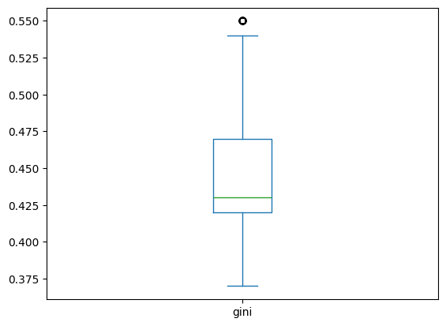

```python
#df.boxplot(column = 'gini')
df['gini'].plot.box()
```

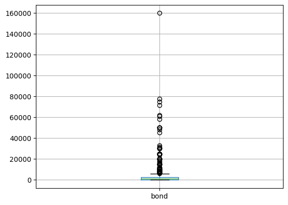

```python
df.boxplot(column = 'bond')
```

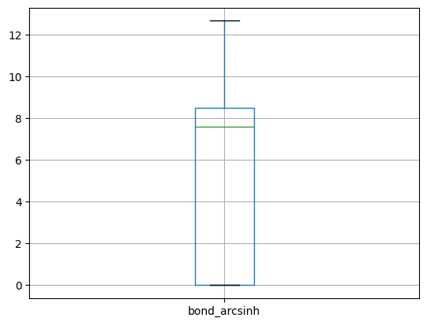

```python
df.boxplot(column = 'bond_arcsinh')
```

## What do you do with outliers?

- Maybe nothing: They're part of the data. Maybe you trim the outliers and drop them, or **windsorize** and replace them with a high or low value.
- The outliers will typically exert *leverage* on the analysis: extreme values will influence the outcomes of your estimates or algorithm (e.g. they disproportionately affect the variance)
- But if the outliers are "really part of the data," that leverage can be totally legitimate: Wildfires, market crashes, earthquakes/tsunamis, data breaches. Sometimes extreme events are the point.
- What you want to be certain of is that the outliers are actually representative of the population of interest --- some observations might have characteristics that make them uncharacteristic of the data you expect to see in the future, and your models will be less useful if they are trained on those data
- The field of *robust statistics* is generally concerned with estimating models when the presence of outliers is likely to interfere with the results

## A Compromise: Winsorizing

- In some cases, we think some observations are fairly extreme and we don't want them to have leverage on our estimates or predictions, but we're also loathe to throw away data
- In this case, we often **winsorize**: For the outliers ( or outside some quantile threshold like .01/.99 or .025/.975) we replace the extremely large and small values with the values of the whiskers. If you do this, you should also make a "winsorized dummy" to note that you edited the data this way.
- How to do this with economical code?

```
count    22986.000000
mean         0.014705
std          0.120370
min          0.000000
25%          0.000000
50%          0.000000
75%          0.000000
max          1.000000
Name: bond, dtype: float64
```

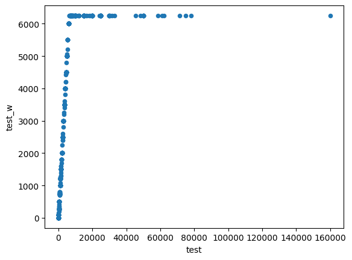

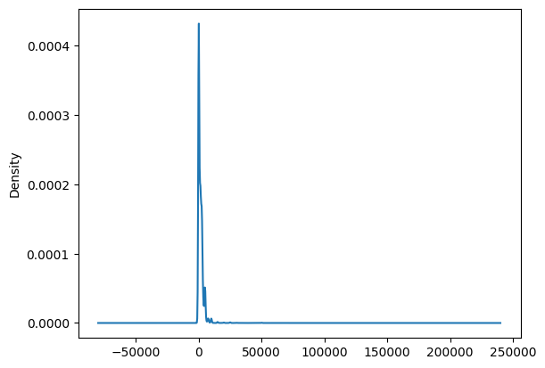

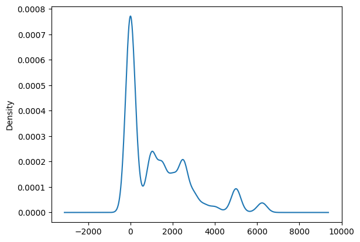

```python
def winsorize(var):
    """ Winsorize a Pandas series, also returning a winsorized dummy. """
    lower = var.quantile(.25)
    upper = var.quantile(.75)
    IQR = upper-lower
    upper_whisker = upper + 3/2 * IQR
    lower_whisker = lower - 3/2 * IQR
    is_outlier =  ( (var > upper_whisker) + (var < lower_whisker) ).astype(int)
    var_w = (var > upper_whisker) * upper_whisker + (var < lower_whisker) * lower_whisker + (1-is_outlier) * var
    return var_w, is_outlier

test = df['bond']
test_w, test_outlier = winsorize(test)
print(test_outlier.describe())
tdf = pd.DataFrame({'test':test, 'test_w':test_w})
tdf.plot.scatter(x='test',y='test_w')
plt.show()

df['bond'].plot.density() # Density plot of raw bonds
plt.show()

tdf['test_w'].plot.density() # Density plot of windsorized bonds
plt.show()
```

- This is an alternative to the log/ihs transformations: Winsorize the outliers to the whisker values
- Choices have consequences: This will likely impact analytics later.

## Variable Descriptions/Summaries

- This is a bunch of ways of slicing the data, and there are many, many more
- Many stats packages report a five-number+ summary: The minimum, the 25%/median/75% percentiles, the maximum, the mean and standard deviation, and how many non-missing observations are recorded (count)
- In Pandas, you can do this with `df[var].describe()`
- From `.describe()`, you can quickly compute almost all the statistics we've mentioned
- The `count` value is the number of non-missing entries

```python
descr = df['age'].describe() # Describe age and save as an object
print(descr,'\n')

# Computing the Variance:
std = descr[2] # Accessing the standard deviation from the description object
var = std**2
print('Variance: ', var,'\n')

# Computing the IQR:
thirdQ = descr[6] # Getting the 75% percentile
firstQ = descr[4] # Getting the 25% percentile
IQR = thirdQ - firstQ # Computing the IQR
print('IQR: ', IQR)
```

```
count    22930.000000
mean        34.278020
std         12.466248
min         18.000000
25%         24.000000
50%         31.000000
75%         42.000000
max        100.000000
Name: age, dtype: float64

Variance:  155.4073279301658

IQR:  18.0
```

## Bivariate EDA

- Up to here, we've looked at a single variable, and ways of summarizing it with plots and statistics
- How do we generalize to two variables (or more, in some cases)?

## Scatter Plots

- Just like cross-tabs allow you to think about two variables at once, scatter plots provide a way of looking at the association between two variables in the data set
- What's a scatterplot? Pick two variables, $x$ and $y$. For each pair of values $(x_i, y_i)$ for observation $i$, you make a dot. Plot all the dots for all observations, $i=1,...,N$.
- The goal is typically to uncover patterns of association between the two variables

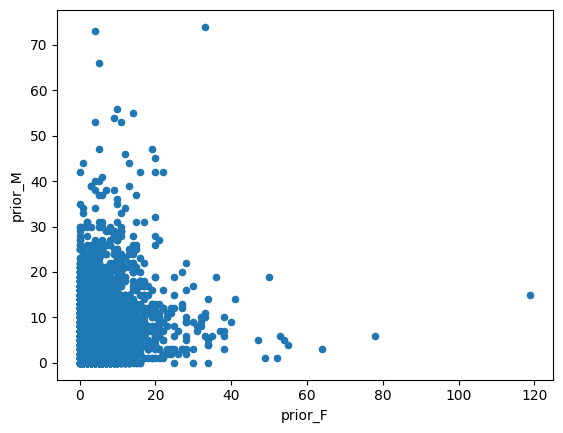

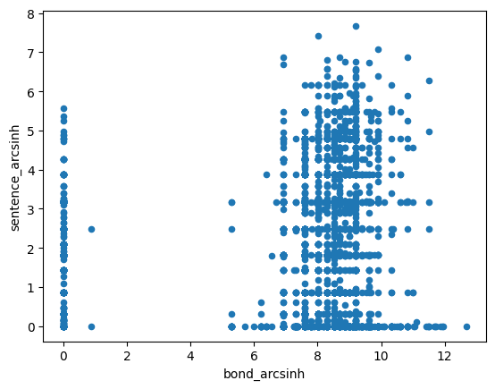

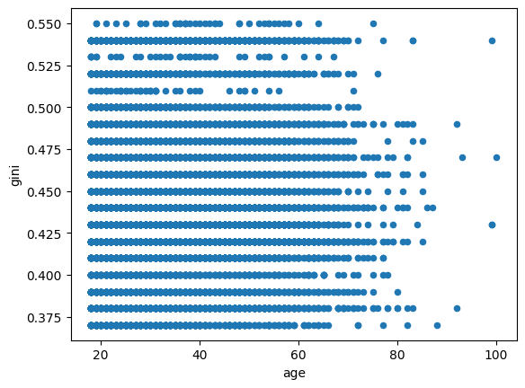

```python
df.plot.scatter(y='prior_M',x='prior_F')
df.plot.scatter(x='bond_arcsinh',y='sentence_arcsinh')
df.plot.scatter(y='gini',x='age')
```

## Statistics: Measures of Association

- Covariance: Essentially, the common variance between two variables \begin{alignat*}{2} \text{cov}(x,y) &=& \dfrac{(x_1-\bar{x})(y_1-\bar{y}) + (x_2-\bar{x})(y_2-\bar{y})+...+(x_N-\bar{x})(y_N-\bar{y}) }{N-1} \\ &=& \dfrac{\sum_{i=1}^{N} (x_i-\bar{x})(y_i-\bar{y}) }{N-1} \end{alignat*}

Notice how $\text{cov}(x,x) = s^2$.

## Covariance and Correlation Matrices

- The function `df.cov()` will compute all of the variances and covariances for everything in your dataframe, and `df.corr()` will compute the correlations
- The output will be a matrix: The variances of the variables will be on the diagonal, and the covariances/correlations will be the off-diagonal terms
- You probably want to use `df.loc[:,list]` to restrict attention to a set of variables in `list`, rather than compute all the possible covariances/correlations

```python
vars = ['prior_M','prior_F']

VCV = df.loc[:,vars].cov() # Compute the variance-covariance matrix for vars
print(VCV,'\n')

cor = df.loc[:,vars].corr() # Compute the correlation matrix for vars
print(cor)
```

```
           prior_M    prior_F
prior_M  19.700497   6.580946
prior_F   6.580946  12.178719

          prior_M   prior_F
prior_M  1.000000  0.424863
prior_F  0.424863  1.000000
```

## Limits of Linear Association

- The covariance and correlation are great tools... but they only capture linear relationships
- If there's a non-linear relationship between two variables, a casual glance at the covariance or correlation might hide it
- Let's illustrate this issue with an example: $y = 10 x^2 + e$ with $x$ values between $-1$ and $1$ and $e$ is normally distributed noise with mean 0 and standard deviation 1.

|  | x | y |
| --- | --- | --- |
| x | 1.000000 | -0.005127 |
| y | -0.005127 | 1.000000 |

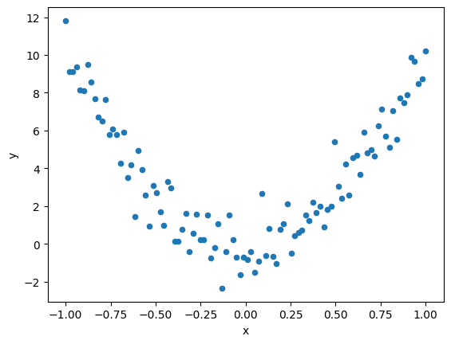

```python
N = 100 # Sample size
rng = np.random.default_rng(90) # Initialize random number generator
e = rng.normal(0, 1, N) # Generate normally distributed errors

X = np.linspace(-1,1,N) # Grid of x values
Y = 10*np.pow(X,2) + e # y = x^2 + e

gdf = pd.DataFrame({'x':X,'y':Y})
gdf.plot.scatter(x='x',y='y')
gdf.corr()
```

|  | x | y |
| --- | --- | --- |
| x | 1.000000 | 0.941642 |
| y | 0.941642 | 1.000000 |

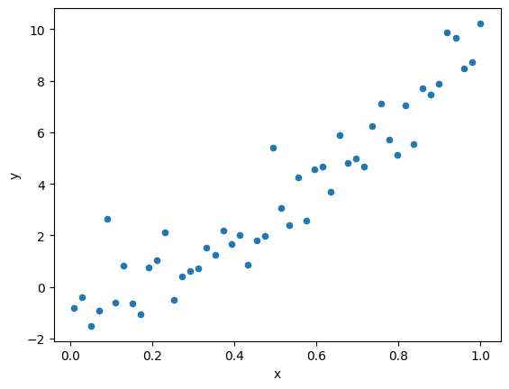

```python
rdf = gdf.loc[gdf['x']>0,:] # Let's look only at the positive values
rdf.plot.scatter(x='x',y='y')
rdf.corr()
```

|  | x | y |
| --- | --- | --- |
| x | 1.000000 | -0.931479 |
| y | -0.931479 | 1.000000 |

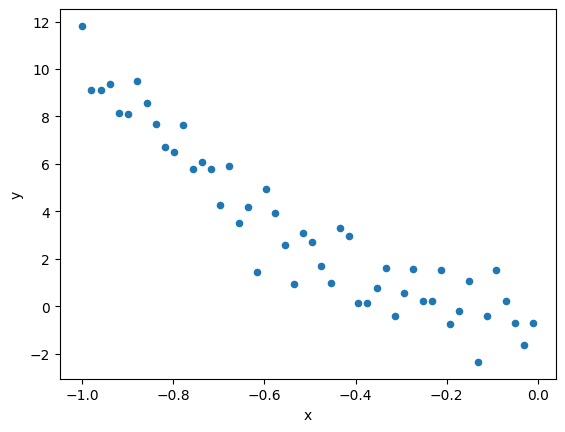

```python
rdf = gdf.loc[gdf['x']<0,:] # Let's look only at the negative values
rdf.plot.scatter(x='x',y='y')
rdf.corr()
```

- I'm not saying covariance or correlation are bad to use; they are bad to **mindlessly** use

## Conditioning or Grouping

```
[Text(0.5, 1.0, 'A Bad Plot')]
```

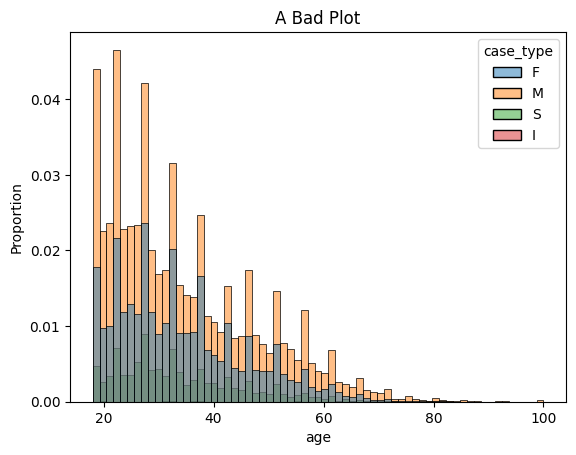

```python
conditioning = 'case_type'
var = 'age' #'bond_arcsinh'
fig = sns.histplot( data=df, x=var, hue=conditioning, stat='proportion')
fig.set(title='A Bad Plot')
```

- Notice that grey and dark green do not appear in the legend: It's unclear who those values belong to
  - For the record, the orange are misdemeanors, the orange plus blue felonies yield the grey, and the dark green is the special cases
  - Why? A mix of Cyan, Magenta, and Yellow yield a desaturated grey. Misdemeanor-Orange is magenta and yellow, and Felony-Blue is cyan and a bit of magenta.
- You should not need to know color theory to understand a plot

## Grouped Kernel Density Plots

- These dominate histograms decisively for illustrating multiple plots at the same time
- I highly highly recommend setting `common_norm = False` so that each density represents its population: Without doing this, the curves are normalized in proportion to their population size, which is typically not the visual comparison I want

```
[Text(0.5, 1.0, 'Grouped KDE Plot')]
```

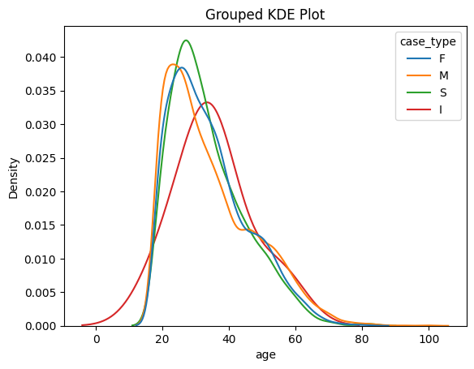

```python
conditioning = 'case_type'
var = 'age' #'bond_arcsinh'
sns.kdeplot( data=df, x=var, hue=conditioning, common_norm=False).set(title='Grouped KDE Plot')
```

```
[Text(0.5, 1.0, 'Grouped KDE Plot')]
```

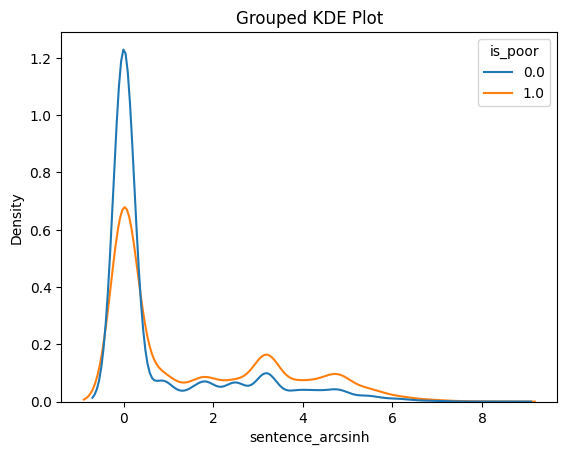

```python
conditioning = 'is_poor'
var = 'sentence_arcsinh'
sns.kdeplot( data=df, x=var, hue=conditioning, common_norm=False).set(title='Grouped KDE Plot')
```

```
[Text(0.5, 1.0, 'Bond by Indigency Status')]
```

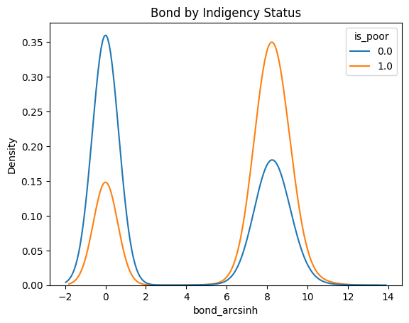

```python
conditioning = 'is_poor'
var = 'bond_arcsinh'
sns.kdeplot( data=df, x=var, hue=conditioning, common_norm=False).set(title='Bond by Indigency Status')
```

```
[Text(0.5, 1.0, 'Sentence by Case Type')]
```

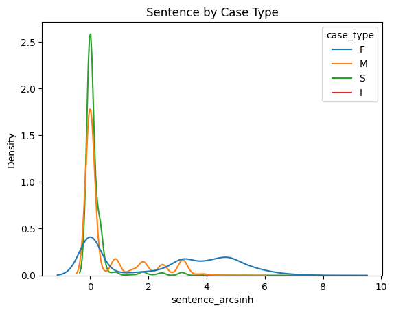

```python
conditioning = 'case_type'
var = 'sentence_arcsinh'
sns.kdeplot( data=df, x=var, hue=conditioning, common_norm=False).set(title='Sentence by Case Type')
```

```
[Text(0.5, 1.0, 'Bond by Case Type')]
```

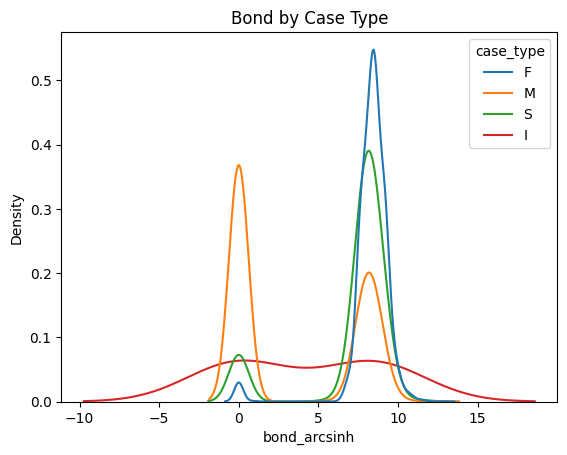

```python
conditioning = 'case_type'
var = 'bond_arcsinh' #'bond_arcsinh'
sns.kdeplot( data=df, x=var, hue=conditioning, common_norm=False).set(title='Bond by Case Type')
```

## Grouped Boxplots

- Grouping for boxplots is even easier: `df.boxplot(column = var, by = group_by)`

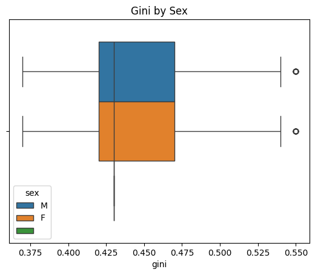

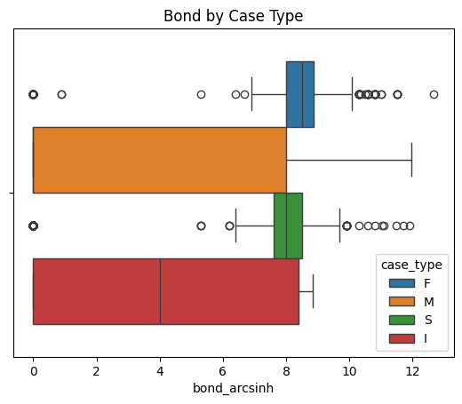

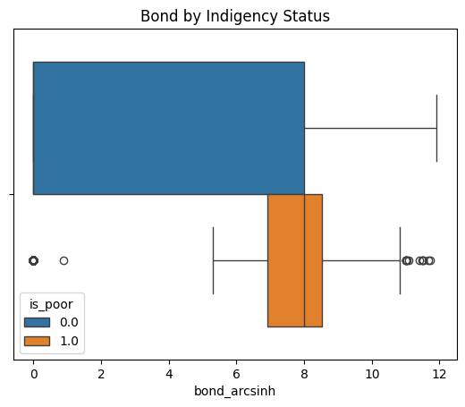

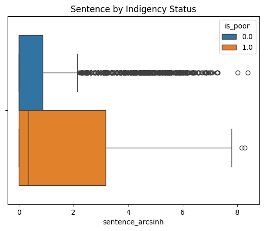

```python
sns.boxplot(data=df, x = 'gini', hue = 'sex').set(title='Gini by Sex')
plt.show()

sns.boxplot(data=df, x = 'bond_arcsinh', hue = 'case_type').set(title='Bond by Case Type')
plt.show()
plt.show()

sns.boxplot(data=df, x = 'bond_arcsinh', hue = 'is_poor').set(title='Bond by Indigency Status')
plt.show()
plt.show()

sns.boxplot(data=df, x = 'sentence_arcsinh', hue = 'is_poor').set(title='Sentence by Indigency Status')
plt.show()
plt.show()
```

## Grouped Scatterplots

- Huing and shaping the marks can be really useful for detecting what's going on in the data:

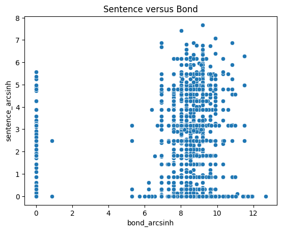

```python
var1 = 'bond_arcsinh' # A numeric variable
var2 = 'sentence_arcsinh' # Another numeric
cat1 = 'case_type' # A categorical variable
cat2 = 'is_poor' # A categorical variable

sns.scatterplot(data=df, x=var1, y=var2).set(title='Sentence versus Bond')
plt.show() # Our initial plot
```

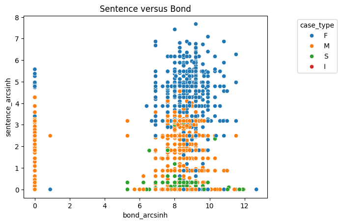

```python
this_plot = sns.scatterplot(data=df, x=var1, y=var2, hue=cat1)
this_plot.set(title='Sentence versus Bond')
sns.move_legend(this_plot, "upper right", bbox_to_anchor=(1.3, 1)) # Moves the Legend
```

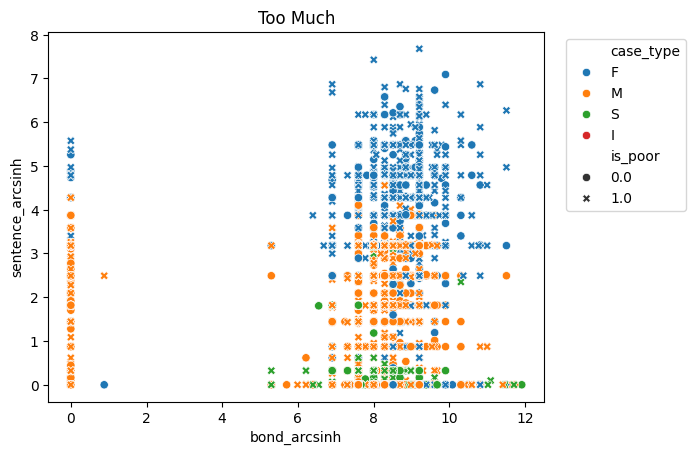

```python
this_plot = sns.scatterplot(data=df, x=var1, y=var2, hue=cat1, style=cat2) # Two kinds of grouping
this_plot.set(title='Too Much')
sns.move_legend(this_plot, "upper right", bbox_to_anchor=(1.3, 1)) # Moves the Legend
```

## Grouped Descriptions

- We can group our calculations like `.describe()` in a similar way to huing or grouping:
  1. Use `df.loc[:,[group,var]]` to get the subset of the dataframe you want to analyze
  2. Then `.groupby(group).describe()` to apply `.describe()` to `var` for each `group`
- Like the grouped kernel densities, this can be a really useful way of adding context to numbers

```python
var = 'bond'
group = 'case_type'
df.loc[:,[group,var]].groupby(group).describe()
```

| case_type | bond count | bond mean | bond std | bond min | bond 25% | bond 50% | bond 75% | bond max |
| --- | --- | --- | --- | --- | --- | --- | --- | --- |
| F | 3040.0 | 3158.421711 | 4448.766214 | 0.0 | 1500.0 | 2500.0 | 3525.0 | 160000.00 |
| I | 6.0 | 1250.000000 | 1508.310313 | 0.0 | 0.0 | 750.0 | 2250.0 | 3500.00 |
| M | 12458.0 | 972.329363 | 2089.762114 | 0.0 | 0.0 | 0.0 | 1500.0 | 78000.00 |
| S | 1387.0 | 2161.847722 | 3548.012111 | 0.0 | 1000.0 | 1500.0 | 2500.0 | 74962.12 |

```python
var = 'bond'
group = 'is_poor'
df.loc[:,[group,var]].groupby(group).describe()
```

| is_poor | bond count | bond mean | bond std | bond min | bond 25% | bond 50% | bond 75% | bond max |
| --- | --- | --- | --- | --- | --- | --- | --- | --- |
| 0.0 | 9450.0 | 1035.299351 | 2255.361676 | 0.0 | 0.0 | 0.0 | 1500.0 | 74962.12 |
| 1.0 | 6632.0 | 1999.594260 | 2828.266454 | 0.0 | 500.0 | 1500.0 | 2500.0 | 61000.00 |

```python
# You can .groupby multiple variables at once:
df.loc[:,['is_poor','case_type','bond']].groupby(['is_poor','case_type']).describe()
```

| is_poor | case_type | bond count | bond mean | bond std | bond min | bond 25% | bond 50% | bond 75% | bond max |
| --- | --- | --- | --- | --- | --- | --- | --- | --- | --- |
| 0.0 | F | 1015.0 | 3270.444335 | 3727.062229 | 0.0 | 1500.0 | 2500.0 | 4000.0 | 50000.00 |
|  | I | 3.0 | 833.333333 | 1443.375673 | 0.0 | 0.0 | 0.0 | 1250.0 | 2500.00 |
|  | M | 7883.0 | 679.544050 | 1611.456941 | 0.0 | 0.0 | 0.0 | 1000.0 | 62195.75 |
|  | S | 539.0 | 2027.332319 | 3581.322416 | 0.0 | 1000.0 | 1500.0 | 2500.0 | 74962.12 |
| 1.0 | F | 1940.0 | 3028.917526 | 3301.773144 | 0.0 | 1500.0 | 2500.0 | 3500.0 | 50000.00 |
|  | I | 3.0 | 1666.666667 | 1755.942292 | 0.0 | 750.0 | 1500.0 | 2500.0 | 3500.00 |
|  | M | 3948.0 | 1428.168303 | 2153.318028 | 0.0 | 0.0 | 1000.0 | 2000.0 | 58529.22 |
|  | S | 733.0 | 2357.845389 | 3723.688027 | 0.0 | 1000.0 | 1500.0 | 2500.0 | 61000.00 |

- So, we can see that for Felony charges, indigency status doesn't seem to influence the outcome, but for Misdemeanor charges it does

## Time Series Data

- Often, we have data collected over time. There's a taxonomy:
  - Cross-Sectional Data: There is a variable $y_i$ recorded for $i = 1, ..., N$ observational units
  - Time Series: There is a variable $y_{t}$ recorded each period $t=0,...,T$
  - Panel Data: Each observational unit $i = 1,...,N$ is recorded in each period $t=0$ up to $t=T$, yielding a panel of data $y_{it}$. If there is an observation $y_{it}$ for each $i$ in each period $t$, the panel is balanced; otherwise it is unbalanced.
- We mostly focus on cross-sectional data in this class: You could easily take two or three courses on time series analysis alone.
- Time Series is like stock prices: Each series just ticks another value each period.
- Panel Data is like clinical trials: There are patients $i$ over time $t$, and patients enter or exit the study, and there might be multiple cohorts or different treatments. A patient $i$ might miss an appointment at time $t$, so the data quality vary across patients.
- Since the points are connected over time, we... connect them over time
- On the analytics side, you can spend as much time as you want studying time series: Whole books, whole courses, whole careers

## Example: U.S. Power Consumption Over Time

- Let's plot United Stats power consumption stats: Where does it come from? How is it generated? How much is used?

```python
tdf = pd.read_csv('./data/us_power_consumption.csv')
tdf.head()
```

|  | Annual Total | Total Fossil Fuels Production (quadBTU) | Nuclear Electric Power Production (quadBTU) | Total Renewable Energy Production (quadBTU) | Total Primary Energy Production (quadBTU) | Primary Energy Imports (quadBTU) | Primary Energy Exports (quadBTU) | Primary Energy Net Imports (quadBTU) | Primary Energy Stock Change and Other (quadBTU) | Total Fossil Fuels Consumption (quadBTU) | Nuclear Electric Power Consumption (quadBTU) | Total Renewable Energy Consumption (quadBTU) | Total Primary Energy Consumption (quadBTU) |
| --- | --- | --- | --- | --- | --- | --- | --- | --- | --- | --- | --- | --- | --- |
| 0 | 1949 | 28.740479 | 0.0 | 1.872627 | 30.613106 | 1.448158 | 1.591760 | -0.143602 | 0.396915 | 28.988371 | 0.0 | 1.872627 | 30.866419 |
| 1 | 1950 | 32.553205 | 0.0 | 1.906525 | 34.459730 | 1.912887 | 1.465322 | 0.447565 | -1.379921 | 31.614755 | 0.0 | 1.906525 | 33.527374 |
| 2 | 1951 | 35.782118 | 0.0 | 1.890800 | 37.672919 | 1.892425 | 2.621545 | -0.729119 | -1.057801 | 33.987736 | 0.0 | 1.890800 | 35.885997 |
| 3 | 1952 | 34.964662 | 0.0 | 1.848694 | 36.813356 | 2.145984 | 2.365131 | -0.219147 | -0.959659 | 33.778116 | 0.0 | 1.848694 | 35.634550 |
| 4 | 1953 | 35.338361 | 0.0 | 1.792616 | 37.130976 | 2.313042 | 1.866013 | 0.447029 | -0.976252 | 34.802286 | 0.0 | 1.792616 | 36.601753 |

[output not shown]

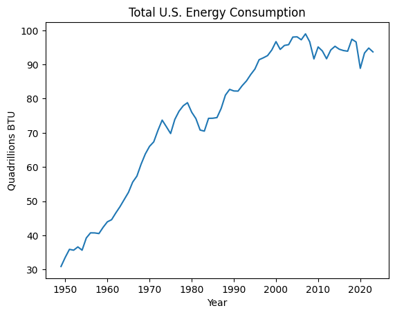

```python
fig = sns.lineplot(data = tdf, x = 'Annual Total',
                   y = 'Total Primary Energy Consumption (quadBTU)')
fig.set(title="Total U.S. Energy Consumption",
        xlabel='Year', ylabel='Quadrillions BTU')
```

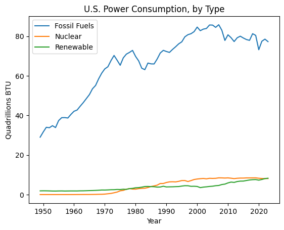

```python
fig = sns.lineplot(data = tdf, x = 'Annual Total',
             y = 'Total Fossil Fuels Consumption (quadBTU)', label = 'Fossil Fuels')
sns.lineplot(data = tdf, x = 'Annual Total',
             y = 'Nuclear Electric Power Consumption (quadBTU)', label = 'Nuclear')
sns.lineplot(data = tdf, x = 'Annual Total',
             y = 'Total Renewable Energy Consumption (quadBTU)', label = 'Renewable')
fig.set(title="U.S. Power Consumption, by Type",
        xlabel='Year', ylabel='Quadrillions BTU')
plt.show()
```

- Huh. Well, moving right along...

## Example: Time Use Data

- How do Americans spend their time over their lives?
- A row gives the fraction of time spent on each activity at that age, a column is an activity
- This format of data comes up a lot, and it is often inconvenient to work with

```python
tdf = pd.read_csv('./data/time_use.csv')
print(tdf.shape)
print(tdf.columns)

tdf = tdf.rename(columns = {'Year':'year',
                            'Time spent alone, by age of respondent (United States)':'alone',
       'Time spent with friends, by age of respondent (United States)':'friends',
       'Time spent with children, by age of respondent (United States)':'children',
       'Time spent with with parents, siblings and other family, by age of respondent (United States)':'family',
       'Time spent with partner, by age of respondent (United States)':'partner',
       'Time spent with coworkers, by age of respondent (United States)':'coworkers'})

# Converts time levels to proportions:
props = tdf.iloc[:,1:7]
tdf.iloc[:,1:7] = props.apply(lambda x: x/x.sum(), axis=1) # Convert minutes to proportions
tdf.head()
```

```
(67, 7)
Index(['Year', 'Time spent alone, by age of respondent (United States)',
       'Time spent with friends, by age of respondent (United States)',
       'Time spent with children, by age of respondent (United States)',
       'Time spent with with parents, siblings and other family, by age of respondent (United States)',
       'Time spent with partner, by age of respondent (United States)',
       'Time spent with coworkers, by age of respondent (United States)'],
      dtype='object')
```

|  | year | alone | friends | children | family | partner | coworkers |
| --- | --- | --- | --- | --- | --- | --- | --- |
| 0 | 15 | 0.321294 | 0.181858 | 0.038999 | 0.443983 | 0.000000 | 0.013865 |
| 1 | 16 | 0.330923 | 0.177579 | 0.045877 | 0.407841 | 0.000049 | 0.037730 |
| 2 | 17 | 0.347324 | 0.186572 | 0.040422 | 0.356066 | 0.001740 | 0.067877 |
| 3 | 18 | 0.331773 | 0.188308 | 0.037439 | 0.323097 | 0.007788 | 0.111595 |
| 4 | 19 | 0.343517 | 0.166577 | 0.046750 | 0.258191 | 0.024810 | 0.160154 |

- I have 6 time series, where the time index is years from 15 to 85.

## Melting Data

- The most common data wrangling problem with time series data is that the data are stored in a matrix where the rows/columns correspond to observations and time, or vice versa
- The `df.melt(id_vars=index)` method turns the columns into rows that correspond to the `index` variable
- This is super useful for all kinds of data, often with a time dimension but not always
- This is essential for making a lot of useful visualizations
- Once the data are in this form, you can use the `index` as the variable on the horizontal axis, the `value` variable on the vertical axis, and hue by `variable` to get a time series plot

```python
hdf = tdf.melt(id_vars='year') # Melt the data
#hdf.head()
print(hdf)
```

```
     year   variable     value
0      15      alone  0.321294
1      16      alone  0.330923
2      17      alone  0.347324
3      18      alone  0.331773
4      19      alone  0.343517
..    ...        ...       ...
397    77  coworkers  0.014065
398    78  coworkers  0.003764
399    79  coworkers  0.005281
400    80  coworkers  0.006094
401    85  coworkers  0.004407

[402 rows x 3 columns]
```

```
[Text(0.5, 1.0, 'Time Use'), Text(0.5, 0, 'Year'), Text(0, 0.5, 'Proportion')]
```

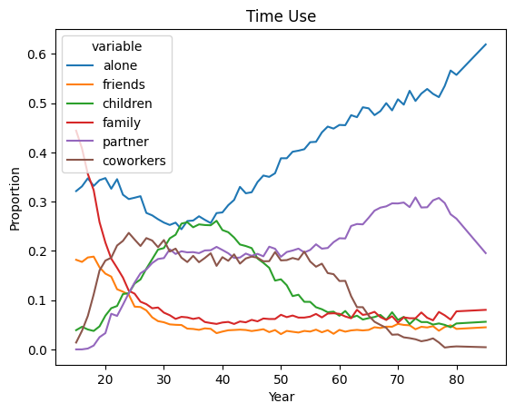

```python
# This is the most depressing graph I've ever made:
fig = sns.lineplot(data=hdf,x='year',y='value',hue='variable')
fig.set(title='Time Use',xlabel='Year',ylabel='Proportion')
```

## Recurrence

- The most basic question to ask about a time series is, "Is there anything to learn from this?"
- A series is **stationary/ergodic** if its statistical properties do not depend on the time period in which it is observed. It is **non-stationary** or **integrated** if the "calendar date" significantly explains its values and behavior.
- You can't really learn about a truly non-ergodic process, since it doesn't repeat itself, so there are no patterns to learn about.
- If you have an integrated time series and want to analyze, you can try to difference it, $z_t = y_t - y_{t-1}$, until it becomes stationary
- Let's look at some tech stocks

```python
tech = ['AAPL', 'MSFT', 'NFLX', 'AMZN', 'META', 'GOOG', 'NVDA', 'FB', ]
tdf = pd.read_csv('./data/tech_stocks.csv', low_memory=False)
tdf.loc[:,'date'] = pd.to_datetime(tdf['date'], format='%Y-%m-%d') # Make date a time variable

print(tdf['symbol'].value_counts())

tdf.head()
```

```
symbol
MSFT    5899
AAPL    5899
AMZN    5899
NVDA    5633
NFLX    4796
FB      2282
GOOG    1816
Name: count, dtype: int64
```

|  | Unnamed: 0 | symbol | date | open | high | low | close | close_adjusted | volume | split_coefficient |
| --- | --- | --- | --- | --- | --- | --- | --- | --- | --- | --- |
| 0 | 0 | MSFT | 2016-05-16 00:00:00 | 50.80 | 51.96 | 50.75 | 51.83 | 49.7013 | 20032017 | 1.0 |
| 1 | 1 | MSFT | 2002-01-16 00:00:00 | 68.85 | 69.84 | 67.85 | 67.87 | 22.5902 | 30977700 | 1.0 |
| 2 | 2 | MSFT | 2001-09-18 00:00:00 | 53.41 | 55.00 | 53.17 | 54.32 | 18.0802 | 41591300 | 1.0 |
| 3 | 3 | MSFT | 2007-10-26 00:00:00 | 36.01 | 36.03 | 34.56 | 35.03 | 27.2232 | 288121200 | 1.0 |
| 4 | 4 | MSFT | 2014-06-27 00:00:00 | 41.61 | 42.29 | 41.51 | 42.25 | 38.6773 | 74640000 | 1.0 |

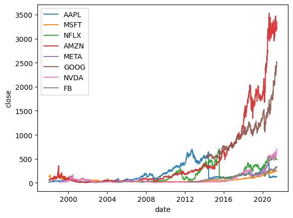

```python
for symbol in tech:
    rdf = tdf[ tdf['symbol'] == symbol ]
    sns.lineplot(x='date',y='close',data=rdf, label = symbol, alpha=.9)
```

```
[Text(0.5, 1.0, 'AMZN')]
```

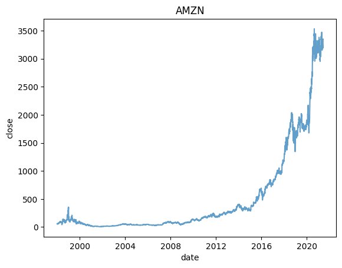

```python
amzn = tdf[ tdf['symbol']=='AMZN' ]
fig = sns.lineplot(x='date',y='close',data=amzn, alpha=.7) # This is not stationary
fig.set(title='AMZN')
```

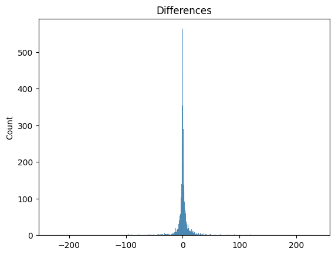

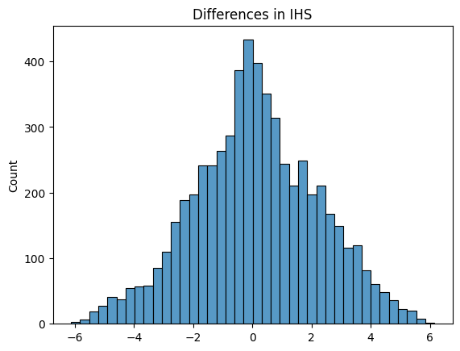

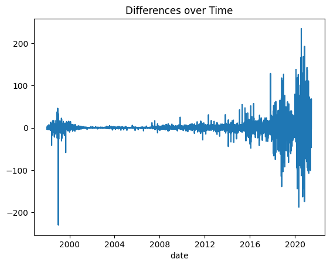

```python
amzn = tdf[ tdf['symbol']=='AMZN' ]
amzn = amzn.sort_values('date')
y = amzn['close'].to_numpy()
t = len(y)

diff = y[1:]-y[:(t-1)] # First difference of Amazon prices

fig = sns.histplot(diff)
fig.set(title='Differences')
plt.show()

fig = sns.histplot(np.arcsinh(diff))
fig.set(title='Differences in IHS')
plt.show()

fig = sns.lineplot(x=amzn['date'][1:],y=diff) # This is stationary
fig.set(title='Differences over Time')
plt.show()
```

- Look at that volatility! Yee-haw!
- The stock price is essentially the integrated sum of draws from the "changes" distribution
- Seriously, there was a tech crash in 2000 called the "dotcom bubble". The volatility around 2000 is nothing compared to post 2016.
- Maybe we should be deflating the prices due to inflation?